# Risk Factor Analysis

## Outcome Variable

**Outcome Variable:** ever_stunted

## Predictor Variables

**Intervention Variable:** birthwt

**Adjustment Set:**

unadjusted

## Stratifying Variables

The analysis was stratified on these variable(s):

- agecat
- studyid
- country

## Data Summary

| agecat | studyid | country | birthwt | ever_stunted | n_cell | n |
| --- | --- | --- | --- | --- | --- | --- |
| 0-24 months (no birth st.) | CMC-V-BCS-2002 | INDIA | Normal or high birthweight | 0 | 27 | 290 |
| 0-24 months (no birth st.) | CMC-V-BCS-2002 | INDIA | Normal or high birthweight | 1 | 249 | 290 |
| 0-24 months (no birth st.) | CMC-V-BCS-2002 | INDIA | Low birthweight | 0 | 1 | 290 |
| 0-24 months (no birth st.) | CMC-V-BCS-2002 | INDIA | Low birthweight | 1 | 13 | 290 |
| 0-24 months (no birth st.) | CMIN | BANGLADESH | Normal or high birthweight | 0 | 7 | 17 |
| 0-24 months (no birth st.) | CMIN | BANGLADESH | Normal or high birthweight | 1 | 6 | 17 |
| 0-24 months (no birth st.) | CMIN | BANGLADESH | Low birthweight | 0 | 3 | 17 |
| 0-24 months (no birth st.) | CMIN | BANGLADESH | Low birthweight | 1 | 1 | 17 |
| 0-24 months (no birth st.) | COHORTS | GUATEMALA | Normal or high birthweight | 0 | 232 | 833 |
| 0-24 months (no birth st.) | COHORTS | GUATEMALA | Normal or high birthweight | 1 | 555 | 833 |
| 0-24 months (no birth st.) | COHORTS | GUATEMALA | Low birthweight | 0 | 6 | 833 |
| 0-24 months (no birth st.) | COHORTS | GUATEMALA | Low birthweight | 1 | 40 | 833 |
| 0-24 months (no birth st.) | COHORTS | INDIA | Normal or high birthweight | 0 | 3828 | 5963 |
| 0-24 months (no birth st.) | COHORTS | INDIA | Normal or high birthweight | 1 | 1337 | 5963 |
| 0-24 months (no birth st.) | COHORTS | INDIA | Low birthweight | 0 | 434 | 5963 |
| 0-24 months (no birth st.) | COHORTS | INDIA | Low birthweight | 1 | 364 | 5963 |
| 0-24 months (no birth st.) | COHORTS | PHILIPPINES | Normal or high birthweight | 0 | 914 | 2830 |
| 0-24 months (no birth st.) | COHORTS | PHILIPPINES | Normal or high birthweight | 1 | 1735 | 2830 |
| 0-24 months (no birth st.) | COHORTS | PHILIPPINES | Low birthweight | 0 | 35 | 2830 |
| 0-24 months (no birth st.) | COHORTS | PHILIPPINES | Low birthweight | 1 | 146 | 2830 |
| 0-24 months (no birth st.) | CONTENT | PERU | Normal or high birthweight | 0 | 1 | 2 |
| 0-24 months (no birth st.) | CONTENT | PERU | Normal or high birthweight | 1 | 1 | 2 |
| 0-24 months (no birth st.) | CONTENT | PERU | Low birthweight | 0 | 0 | 2 |
| 0-24 months (no birth st.) | CONTENT | PERU | Low birthweight | 1 | 0 | 2 |
| 0-24 months (no birth st.) | EE | PAKISTAN | Normal or high birthweight | 0 | 39 | 213 |
| 0-24 months (no birth st.) | EE | PAKISTAN | Normal or high birthweight | 1 | 136 | 213 |
| 0-24 months (no birth st.) | EE | PAKISTAN | Low birthweight | 0 | 2 | 213 |
| 0-24 months (no birth st.) | EE | PAKISTAN | Low birthweight | 1 | 36 | 213 |
| 0-24 months (no birth st.) | GMS-Nepal | NEPAL | Normal or high birthweight | 0 | 214 | 575 |
| 0-24 months (no birth st.) | GMS-Nepal | NEPAL | Normal or high birthweight | 1 | 240 | 575 |

[output cut: 270 more lines]

The following strata were considered:

- agecat: 0-24 months (no birth st.), studyid: CMC-V-BCS-2002, country: INDIA
- agecat: 0-24 months (no birth st.), studyid: CMIN, country: BANGLADESH
- agecat: 0-24 months (no birth st.), studyid: COHORTS, country: GUATEMALA
- agecat: 0-24 months (no birth st.), studyid: COHORTS, country: INDIA
- agecat: 0-24 months (no birth st.), studyid: COHORTS, country: PHILIPPINES
- agecat: 0-24 months (no birth st.), studyid: CONTENT, country: PERU
- agecat: 0-24 months (no birth st.), studyid: EE, country: PAKISTAN
- agecat: 0-24 months (no birth st.), studyid: GMS-Nepal, country: NEPAL
- agecat: 0-24 months (no birth st.), studyid: IRC, country: INDIA
- agecat: 0-24 months (no birth st.), studyid: Keneba, country: GAMBIA
- agecat: 0-24 months (no birth st.), studyid: MAL-ED, country: BANGLADESH
- agecat: 0-24 months (no birth st.), studyid: MAL-ED, country: BRAZIL
- agecat: 0-24 months (no birth st.), studyid: MAL-ED, country: INDIA
- agecat: 0-24 months (no birth st.), studyid: MAL-ED, country: NEPAL
- agecat: 0-24 months (no birth st.), studyid: MAL-ED, country: PERU
- agecat: 0-24 months (no birth st.), studyid: MAL-ED, country: SOUTH AFRICA
- agecat: 0-24 months (no birth st.), studyid: MAL-ED, country: TANZANIA, UNITED REPUBLIC OF
- agecat: 0-24 months (no birth st.), studyid: NIH-Birth, country: BANGLADESH
- agecat: 0-24 months (no birth st.), studyid: NIH-Crypto, country: BANGLADESH
- agecat: 0-24 months (no birth st.), studyid: PROBIT, country: BELARUS
- agecat: 0-24 months (no birth st.), studyid: PROVIDE, country: BANGLADESH
- agecat: 0-24 months (no birth st.), studyid: ResPak, country: PAKISTAN
- agecat: 0-24 months (no birth st.), studyid: SAS-CompFeed, country: INDIA
- agecat: 0-24 months (no birth st.), studyid: TanzaniaChild2, country: TANZANIA, UNITED REPUBLIC OF
- agecat: 0-24 months (no birth st.), studyid: ZVITAMBO, country: ZIMBABWE
- agecat: 0-6 months (no birth st.), studyid: CMC-V-BCS-2002, country: INDIA
- agecat: 0-6 months (no birth st.), studyid: CMIN, country: BANGLADESH
- agecat: 0-6 months (no birth st.), studyid: COHORTS, country: GUATEMALA
- agecat: 0-6 months (no birth st.), studyid: COHORTS, country: INDIA
- agecat: 0-6 months (no birth st.), studyid: COHORTS, country: PHILIPPINES
- agecat: 0-6 months (no birth st.), studyid: CONTENT, country: PERU
- agecat: 0-6 months (no birth st.), studyid: EE, country: PAKISTAN
- agecat: 0-6 months (no birth st.), studyid: GMS-Nepal, country: NEPAL
- agecat: 0-6 months (no birth st.), studyid: IRC, country: INDIA
- agecat: 0-6 months (no birth st.), studyid: Keneba, country: GAMBIA
- agecat: 0-6 months (no birth st.), studyid: MAL-ED, country: BANGLADESH
- agecat: 0-6 months (no birth st.), studyid: MAL-ED, country: BRAZIL
- agecat: 0-6 months (no birth st.), studyid: MAL-ED, country: INDIA
- agecat: 0-6 months (no birth st.), studyid: MAL-ED, country: NEPAL
- agecat: 0-6 months (no birth st.), studyid: MAL-ED, country: PERU
- agecat: 0-6 months (no birth st.), studyid: MAL-ED, country: SOUTH AFRICA
- agecat: 0-6 months (no birth st.), studyid: MAL-ED, country: TANZANIA, UNITED REPUBLIC OF
- agecat: 0-6 months (no birth st.), studyid: NIH-Birth, country: BANGLADESH
- agecat: 0-6 months (no birth st.), studyid: NIH-Crypto, country: BANGLADESH
- agecat: 0-6 months (no birth st.), studyid: PROBIT, country: BELARUS
- agecat: 0-6 months (no birth st.), studyid: PROVIDE, country: BANGLADESH
- agecat: 0-6 months (no birth st.), studyid: ResPak, country: PAKISTAN
- agecat: 0-6 months (no birth st.), studyid: SAS-CompFeed, country: INDIA
- agecat: 0-6 months (no birth st.), studyid: TanzaniaChild2, country: TANZANIA, UNITED REPUBLIC OF
- agecat: 0-6 months (no birth st.), studyid: ZVITAMBO, country: ZIMBABWE
- agecat: 6-24 months, studyid: CMC-V-BCS-2002, country: INDIA
- agecat: 6-24 months, studyid: CMIN, country: BANGLADESH
- agecat: 6-24 months, studyid: COHORTS, country: GUATEMALA
- agecat: 6-24 months, studyid: COHORTS, country: INDIA
- agecat: 6-24 months, studyid: COHORTS, country: PHILIPPINES
- agecat: 6-24 months, studyid: CONTENT, country: PERU
- agecat: 6-24 months, studyid: EE, country: PAKISTAN
- agecat: 6-24 months, studyid: GMS-Nepal, country: NEPAL
- agecat: 6-24 months, studyid: IRC, country: INDIA
- agecat: 6-24 months, studyid: Keneba, country: GAMBIA
- agecat: 6-24 months, studyid: MAL-ED, country: BANGLADESH
- agecat: 6-24 months, studyid: MAL-ED, country: BRAZIL
- agecat: 6-24 months, studyid: MAL-ED, country: INDIA
- agecat: 6-24 months, studyid: MAL-ED, country: NEPAL
- agecat: 6-24 months, studyid: MAL-ED, country: PERU
- agecat: 6-24 months, studyid: MAL-ED, country: SOUTH AFRICA
- agecat: 6-24 months, studyid: MAL-ED, country: TANZANIA, UNITED REPUBLIC OF
- agecat: 6-24 months, studyid: NIH-Birth, country: BANGLADESH
- agecat: 6-24 months, studyid: NIH-Crypto, country: BANGLADESH
- agecat: 6-24 months, studyid: PROBIT, country: BELARUS
- agecat: 6-24 months, studyid: PROVIDE, country: BANGLADESH
- agecat: 6-24 months, studyid: ResPak, country: PAKISTAN
- agecat: 6-24 months, studyid: SAS-CompFeed, country: INDIA
- agecat: 6-24 months, studyid: TanzaniaChild2, country: TANZANIA, UNITED REPUBLIC OF
- agecat: 6-24 months, studyid: ZVITAMBO, country: ZIMBABWE

### Dropped Strata

Some strata were dropped due to rare outcomes:

- agecat: 0-24 months (no birth st.), studyid: CMC-V-BCS-2002, country: INDIA
- agecat: 0-24 months (no birth st.), studyid: CMIN, country: BANGLADESH
- agecat: 0-24 months (no birth st.), studyid: CONTENT, country: PERU
- agecat: 0-24 months (no birth st.), studyid: EE, country: PAKISTAN
- agecat: 0-24 months (no birth st.), studyid: MAL-ED, country: BRAZIL
- agecat: 0-24 months (no birth st.), studyid: MAL-ED, country: NEPAL
- agecat: 0-24 months (no birth st.), studyid: MAL-ED, country: PERU
- agecat: 0-24 months (no birth st.), studyid: MAL-ED, country: SOUTH AFRICA
- agecat: 0-24 months (no birth st.), studyid: MAL-ED, country: TANZANIA, UNITED REPUBLIC OF
- agecat: 0-24 months (no birth st.), studyid: PROBIT, country: BELARUS
- agecat: 0-24 months (no birth st.), studyid: ResPak, country: PAKISTAN
- agecat: 0-6 months (no birth st.), studyid: CMC-V-BCS-2002, country: INDIA
- agecat: 0-6 months (no birth st.), studyid: CMIN, country: BANGLADESH
- agecat: 0-6 months (no birth st.), studyid: CONTENT, country: PERU
- agecat: 0-6 months (no birth st.), studyid: MAL-ED, country: BRAZIL
- agecat: 0-6 months (no birth st.), studyid: MAL-ED, country: NEPAL
- agecat: 0-6 months (no birth st.), studyid: MAL-ED, country: PERU
- agecat: 0-6 months (no birth st.), studyid: MAL-ED, country: SOUTH AFRICA
- agecat: 0-6 months (no birth st.), studyid: MAL-ED, country: TANZANIA, UNITED REPUBLIC OF
- agecat: 0-6 months (no birth st.), studyid: PROBIT, country: BELARUS
- agecat: 0-6 months (no birth st.), studyid: ResPak, country: PAKISTAN
- agecat: 6-24 months, studyid: CMC-V-BCS-2002, country: INDIA
- agecat: 6-24 months, studyid: CMIN, country: BANGLADESH
- agecat: 6-24 months, studyid: COHORTS, country: GUATEMALA
- agecat: 6-24 months, studyid: CONTENT, country: PERU
- agecat: 6-24 months, studyid: EE, country: PAKISTAN
- agecat: 6-24 months, studyid: MAL-ED, country: BANGLADESH
- agecat: 6-24 months, studyid: MAL-ED, country: BRAZIL
- agecat: 6-24 months, studyid: MAL-ED, country: NEPAL
- agecat: 6-24 months, studyid: MAL-ED, country: PERU
- agecat: 6-24 months, studyid: MAL-ED, country: SOUTH AFRICA
- agecat: 6-24 months, studyid: MAL-ED, country: TANZANIA, UNITED REPUBLIC OF
- agecat: 6-24 months, studyid: PROBIT, country: BELARUS
- agecat: 6-24 months, studyid: ResPak, country: PAKISTAN

## Methods Detail

We’re interested in the causal parameters $E[Y_a]$ for all values of $a \in \mathcal{A}$. These parameters represent the mean outcome if, possibly contrary to fact, we intervened to set all units to have $A=a$. Under the randomization and positivity assumptions, these are identified by the statistical parameters $\psi_a=E_W[E_{Y|A,W}(Y|A=a,W)]$. In addition, we’re interested in the mean of $Y$, $E[Y]$ under no intervention (the observed mean). We will estimate these parameters by using SuperLearner to fit the relevant likelihood factors – $E_{Y|A,W}(Y|A=a,W)$ and $p(A=a|W)$, and then updating our likelihood fit using a joint TMLE.

For unadjusted analyses ($W=\{\}$), initial likelihoods were estimated using Lrnr_glm to estimate the simple $E(Y|A)$ and Lrnr_mean to estimate $p(A)$. For adjusted analyses, a small library containing Lrnr_glmnet, Lrnr_xgboost, and Lrnr_mean was used.

Having estimated these parameters, we will then use the delta method to estimate relative risks and attributable risks relative to a prespecified baseline level of $A$.

# Results Detail

## Results Plots

[figure not shown]

[figure not shown]

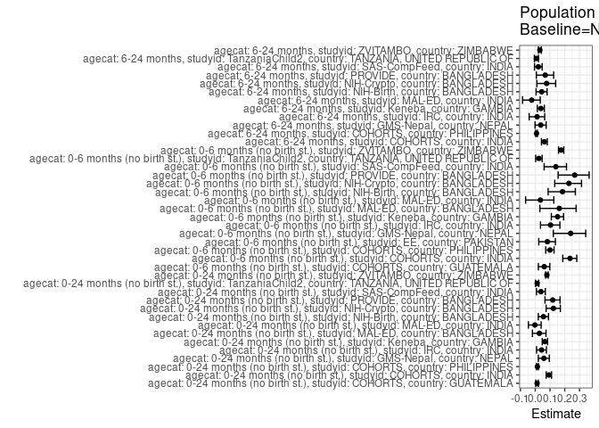

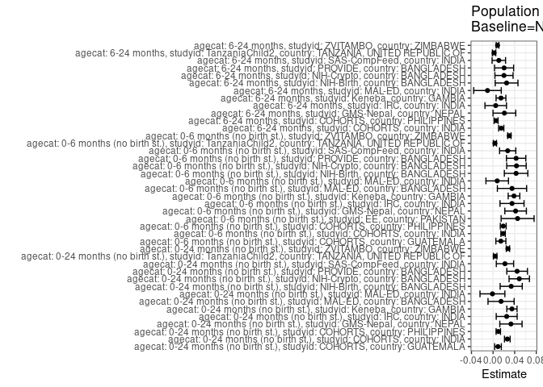

## Results Table

### Parameter: TSM

| agecat | studyid | country | intervention_level | baseline_level | estimate | ci_lower | ci_upper |
| --- | --- | --- | --- | --- | --- | --- | --- |
| 0-24 months (no birth st.) | COHORTS | GUATEMALA | Normal or high birthweight | NA | 0.7052097 | 0.6733356 | 0.7370837 |
| 0-24 months (no birth st.) | COHORTS | GUATEMALA | Low birthweight | NA | 0.8695652 | 0.7721834 | 0.9669470 |
| 0-24 months (no birth st.) | COHORTS | INDIA | Normal or high birthweight | NA | 0.2588577 | 0.2469115 | 0.2708039 |
| 0-24 months (no birth st.) | COHORTS | INDIA | Low birthweight | NA | 0.4561404 | 0.4215802 | 0.4907005 |
| 0-24 months (no birth st.) | COHORTS | PHILIPPINES | Normal or high birthweight | NA | 0.6549641 | 0.6368580 | 0.6730702 |
| 0-24 months (no birth st.) | COHORTS | PHILIPPINES | Low birthweight | NA | 0.8066298 | 0.7490835 | 0.8641761 |
| 0-24 months (no birth st.) | GMS-Nepal | NEPAL | Normal or high birthweight | NA | 0.5286344 | 0.4826770 | 0.5745917 |
| 0-24 months (no birth st.) | GMS-Nepal | NEPAL | Low birthweight | NA | 0.6859504 | 0.6031793 | 0.7687215 |
| 0-24 months (no birth st.) | IRC | INDIA | Normal or high birthweight | NA | 0.5635179 | 0.5079622 | 0.6190736 |
| 0-24 months (no birth st.) | IRC | INDIA | Low birthweight | NA | 0.7500000 | 0.6273294 | 0.8726706 |
| 0-24 months (no birth st.) | Keneba | GAMBIA | Normal or high birthweight | NA | 0.4956930 | 0.4682611 | 0.5231249 |
| 0-24 months (no birth st.) | Keneba | GAMBIA | Low birthweight | NA | 0.7808989 | 0.7201124 | 0.8416854 |
| 0-24 months (no birth st.) | MAL-ED | BANGLADESH | Normal or high birthweight | NA | 0.5132275 | 0.4418022 | 0.5846528 |
| 0-24 months (no birth st.) | MAL-ED | BANGLADESH | Low birthweight | NA | 0.6400000 | 0.4514023 | 0.8285977 |
| 0-24 months (no birth st.) | MAL-ED | INDIA | Normal or high birthweight | NA | 0.5351351 | 0.4630885 | 0.6071818 |
| 0-24 months (no birth st.) | MAL-ED | INDIA | Low birthweight | NA | 0.5238095 | 0.3096822 | 0.7379369 |
| 0-24 months (no birth st.) | NIH-Birth | BANGLADESH | Normal or high birthweight | NA | 0.5672372 | 0.5191733 | 0.6153011 |
| 0-24 months (no birth st.) | NIH-Birth | BANGLADESH | Low birthweight | NA | 0.7352941 | 0.6495932 | 0.8209951 |
| 0-24 months (no birth st.) | NIH-Crypto | BANGLADESH | Normal or high birthweight | NA | 0.3450835 | 0.3049191 | 0.3852479 |
| 0-24 months (no birth st.) | NIH-Crypto | BANGLADESH | Low birthweight | NA | 0.6228070 | 0.5337666 | 0.7118474 |
| 0-24 months (no birth st.) | PROVIDE | BANGLADESH | Normal or high birthweight | NA | 0.3314176 | 0.2910046 | 0.3718307 |
| 0-24 months (no birth st.) | PROVIDE | BANGLADESH | Low birthweight | NA | 0.5855856 | 0.4938701 | 0.6773010 |
| 0-24 months (no birth st.) | SAS-CompFeed | INDIA | Normal or high birthweight | NA | 0.5441329 | 0.4780701 | 0.6101958 |
| 0-24 months (no birth st.) | SAS-CompFeed | INDIA | Low birthweight | NA | 0.7457627 | 0.6452888 | 0.8462366 |
| 0-24 months (no birth st.) | TanzaniaChild2 | TANZANIA, UNITED REPUBLIC OF | Normal or high birthweight | NA | 0.2946346 | 0.2753580 | 0.3139112 |
| 0-24 months (no birth st.) | TanzaniaChild2 | TANZANIA, UNITED REPUBLIC OF | Low birthweight | NA | 0.4693878 | 0.3454881 | 0.5932874 |
| 0-24 months (no birth st.) | ZVITAMBO | ZIMBABWE | Normal or high birthweight | NA | 0.3212340 | 0.3126536 | 0.3298143 |
| 0-24 months (no birth st.) | ZVITAMBO | ZIMBABWE | Low birthweight | NA | 0.6155158 | 0.5876754 | 0.6433562 |
| 0-6 months (no birth st.) | COHORTS | GUATEMALA | Normal or high birthweight | NA | 0.2226563 | 0.1932149 | 0.2520976 |
| 0-6 months (no birth st.) | COHORTS | GUATEMALA | Low birthweight | NA | 0.4782609 | 0.3338183 | 0.6227034 |

[output cut: 52 more lines]

### Parameter: E(Y)

| agecat | studyid | country | intervention_level | baseline_level | estimate | ci_lower | ci_upper |
| --- | --- | --- | --- | --- | --- | --- | --- |
| 0-24 months (no birth st.) | COHORTS | GUATEMALA | NA | NA | 0.7142857 | 0.6835892 | 0.7449822 |
| 0-24 months (no birth st.) | COHORTS | INDIA | NA | NA | 0.2852591 | 0.2737975 | 0.2967207 |
| 0-24 months (no birth st.) | COHORTS | PHILIPPINES | NA | NA | 0.6646643 | 0.6472674 | 0.6820612 |
| 0-24 months (no birth st.) | GMS-Nepal | NEPAL | NA | NA | 0.5617391 | 0.5211485 | 0.6023298 |
| 0-24 months (no birth st.) | IRC | INDIA | NA | NA | 0.5887324 | 0.5374737 | 0.6399911 |
| 0-24 months (no birth st.) | Keneba | GAMBIA | NA | NA | 0.5305842 | 0.5049322 | 0.5562362 |
| 0-24 months (no birth st.) | MAL-ED | BANGLADESH | NA | NA | 0.5280374 | 0.4609958 | 0.5950790 |
| 0-24 months (no birth st.) | MAL-ED | INDIA | NA | NA | 0.5339806 | 0.4656939 | 0.6022672 |
| 0-24 months (no birth st.) | NIH-Birth | BANGLADESH | NA | NA | 0.6007828 | 0.5582791 | 0.6432864 |
| 0-24 months (no birth st.) | NIH-Crypto | BANGLADESH | NA | NA | 0.3935681 | 0.3560687 | 0.4310676 |
| 0-24 months (no birth st.) | PROVIDE | BANGLADESH | NA | NA | 0.3759874 | 0.3382238 | 0.4137509 |
| 0-24 months (no birth st.) | SAS-CompFeed | INDIA | NA | NA | 0.5661425 | 0.5076572 | 0.6246278 |
| 0-24 months (no birth st.) | TanzaniaChild2 | TANZANIA, UNITED REPUBLIC OF | NA | NA | 0.2985075 | 0.2794291 | 0.3175858 |
| 0-24 months (no birth st.) | ZVITAMBO | ZIMBABWE | NA | NA | 0.3487372 | 0.3403993 | 0.3570750 |
| 0-6 months (no birth st.) | COHORTS | GUATEMALA | NA | NA | 0.2371007 | 0.2078658 | 0.2663357 |
| 0-6 months (no birth st.) | COHORTS | INDIA | NA | NA | 0.0788439 | 0.0719356 | 0.0857521 |
| 0-6 months (no birth st.) | COHORTS | PHILIPPINES | NA | NA | 0.1886926 | 0.1742747 | 0.2031105 |
| 0-6 months (no birth st.) | EE | PAKISTAN | NA | NA | 0.5539906 | 0.4870787 | 0.6209025 |
| 0-6 months (no birth st.) | GMS-Nepal | NEPAL | NA | NA | 0.1739130 | 0.1429052 | 0.2049209 |
| 0-6 months (no birth st.) | IRC | INDIA | NA | NA | 0.3380282 | 0.2887514 | 0.3873050 |
| 0-6 months (no birth st.) | Keneba | GAMBIA | NA | NA | 0.2556701 | 0.2332474 | 0.2780928 |
| 0-6 months (no birth st.) | MAL-ED | BANGLADESH | NA | NA | 0.2149533 | 0.1597864 | 0.2701201 |
| 0-6 months (no birth st.) | MAL-ED | INDIA | NA | NA | 0.2184466 | 0.1618848 | 0.2750084 |
| 0-6 months (no birth st.) | NIH-Birth | BANGLADESH | NA | NA | 0.2309198 | 0.1943452 | 0.2674943 |
| 0-6 months (no birth st.) | NIH-Crypto | BANGLADESH | NA | NA | 0.1898928 | 0.1597870 | 0.2199986 |
| 0-6 months (no birth st.) | PROVIDE | BANGLADESH | NA | NA | 0.1595577 | 0.1310079 | 0.1881074 |
| 0-6 months (no birth st.) | SAS-CompFeed | INDIA | NA | NA | 0.1944444 | 0.1700545 | 0.2188344 |
| 0-6 months (no birth st.) | TanzaniaChild2 | TANZANIA, UNITED REPUBLIC OF | NA | NA | 0.1356852 | 0.1214076 | 0.1499628 |
| 0-6 months (no birth st.) | ZVITAMBO | ZIMBABWE | NA | NA | 0.1716108 | 0.1650114 | 0.1782103 |
| 6-24 months | COHORTS | INDIA | NA | NA | 0.2440256 | 0.2322906 | 0.2557607 |
| 6-24 months | COHORTS | PHILIPPINES | NA | NA | 0.6435738 | 0.6230503 | 0.6640973 |
| 6-24 months | GMS-Nepal | NEPAL | NA | NA | 0.5631313 | 0.5142177 | 0.6120449 |
| 6-24 months | IRC | INDIA | NA | NA | 0.3787234 | 0.3165730 | 0.4408738 |
| 6-24 months | Keneba | GAMBIA | NA | NA | 0.3827751 | 0.3532908 | 0.4122595 |
| 6-24 months | MAL-ED | INDIA | NA | NA | 0.4276316 | 0.3487215 | 0.5065416 |
| 6-24 months | NIH-Birth | BANGLADESH | NA | NA | 0.5727273 | 0.5192737 | 0.6261808 |
| 6-24 months | NIH-Crypto | BANGLADESH | NA | NA | 0.2628458 | 0.2244546 | 0.3012371 |
| 6-24 months | PROVIDE | BANGLADESH | NA | NA | 0.3004386 | 0.2583143 | 0.3425629 |
| 6-24 months | SAS-CompFeed | INDIA | NA | NA | 0.5018680 | 0.4570583 | 0.5466777 |
| 6-24 months | TanzaniaChild2 | TANZANIA, UNITED REPUBLIC OF | NA | NA | 0.2265576 | 0.2059690 | 0.2471462 |
| 6-24 months | ZVITAMBO | ZIMBABWE | NA | NA | 0.2633691 | 0.2539889 | 0.2727494 |

### Parameter: RR

| agecat | studyid | country | intervention_level | baseline_level | estimate | ci_lower | ci_upper |
| --- | --- | --- | --- | --- | --- | --- | --- |
| 0-24 months (no birth st.) | COHORTS | GUATEMALA | Normal or high birthweight | Normal or high birthweight | 1.0000000 | 1.0000000 | 1.000000 |
| 0-24 months (no birth st.) | COHORTS | GUATEMALA | Low birthweight | Normal or high birthweight | 1.2330591 | 1.0927880 | 1.391336 |
| 0-24 months (no birth st.) | COHORTS | INDIA | Normal or high birthweight | Normal or high birthweight | 1.0000000 | 1.0000000 | 1.000000 |
| 0-24 months (no birth st.) | COHORTS | INDIA | Low birthweight | Normal or high birthweight | 1.7621278 | 1.6125342 | 1.925599 |
| 0-24 months (no birth st.) | COHORTS | PHILIPPINES | Normal or high birthweight | Normal or high birthweight | 1.0000000 | 1.0000000 | 1.000000 |
| 0-24 months (no birth st.) | COHORTS | PHILIPPINES | Low birthweight | Normal or high birthweight | 1.2315634 | 1.1408504 | 1.329489 |
| 0-24 months (no birth st.) | GMS-Nepal | NEPAL | Normal or high birthweight | Normal or high birthweight | 1.0000000 | 1.0000000 | 1.000000 |
| 0-24 months (no birth st.) | GMS-Nepal | NEPAL | Low birthweight | Normal or high birthweight | 1.2975895 | 1.1182739 | 1.505658 |
| 0-24 months (no birth st.) | IRC | INDIA | Normal or high birthweight | Normal or high birthweight | 1.0000000 | 1.0000000 | 1.000000 |
| 0-24 months (no birth st.) | IRC | INDIA | Low birthweight | Normal or high birthweight | 1.3309249 | 1.0995474 | 1.610991 |
| 0-24 months (no birth st.) | Keneba | GAMBIA | Normal or high birthweight | Normal or high birthweight | 1.0000000 | 1.0000000 | 1.000000 |
| 0-24 months (no birth st.) | Keneba | GAMBIA | Low birthweight | Normal or high birthweight | 1.5753679 | 1.4318684 | 1.733249 |
| 0-24 months (no birth st.) | MAL-ED | BANGLADESH | Normal or high birthweight | Normal or high birthweight | 1.0000000 | 1.0000000 | 1.000000 |
| 0-24 months (no birth st.) | MAL-ED | BANGLADESH | Low birthweight | Normal or high birthweight | 1.2470103 | 0.9001943 | 1.727443 |
| 0-24 months (no birth st.) | MAL-ED | INDIA | Normal or high birthweight | Normal or high birthweight | 1.0000000 | 1.0000000 | 1.000000 |
| 0-24 months (no birth st.) | MAL-ED | INDIA | Low birthweight | Normal or high birthweight | 0.9788360 | 0.6364945 | 1.505307 |
| 0-24 months (no birth st.) | NIH-Birth | BANGLADESH | Normal or high birthweight | Normal or high birthweight | 1.0000000 | 1.0000000 | 1.000000 |
| 0-24 months (no birth st.) | NIH-Birth | BANGLADESH | Low birthweight | Normal or high birthweight | 1.2962728 | 1.1223160 | 1.497193 |
| 0-24 months (no birth st.) | NIH-Crypto | BANGLADESH | Normal or high birthweight | Normal or high birthweight | 1.0000000 | 1.0000000 | 1.000000 |
| 0-24 months (no birth st.) | NIH-Crypto | BANGLADESH | Low birthweight | Normal or high birthweight | 1.8048010 | 1.5009484 | 2.170166 |
| 0-24 months (no birth st.) | PROVIDE | BANGLADESH | Normal or high birthweight | Normal or high birthweight | 1.0000000 | 1.0000000 | 1.000000 |
| 0-24 months (no birth st.) | PROVIDE | BANGLADESH | Low birthweight | Normal or high birthweight | 1.7669114 | 1.4488055 | 2.154862 |
| 0-24 months (no birth st.) | SAS-CompFeed | INDIA | Normal or high birthweight | Normal or high birthweight | 1.0000000 | 1.0000000 | 1.000000 |
| 0-24 months (no birth st.) | SAS-CompFeed | INDIA | Low birthweight | Normal or high birthweight | 1.3705525 | 1.1416607 | 1.645335 |
| 0-24 months (no birth st.) | TanzaniaChild2 | TANZANIA, UNITED REPUBLIC OF | Normal or high birthweight | Normal or high birthweight | 1.0000000 | 1.0000000 | 1.000000 |
| 0-24 months (no birth st.) | TanzaniaChild2 | TANZANIA, UNITED REPUBLIC OF | Low birthweight | Normal or high birthweight | 1.5931183 | 1.2137877 | 2.090997 |
| 0-24 months (no birth st.) | ZVITAMBO | ZIMBABWE | Normal or high birthweight | Normal or high birthweight | 1.0000000 | 1.0000000 | 1.000000 |
| 0-24 months (no birth st.) | ZVITAMBO | ZIMBABWE | Low birthweight | Normal or high birthweight | 1.9160981 | 1.8180453 | 2.019439 |
| 0-6 months (no birth st.) | COHORTS | GUATEMALA | Normal or high birthweight | Normal or high birthweight | 1.0000000 | 1.0000000 | 1.000000 |
| 0-6 months (no birth st.) | COHORTS | GUATEMALA | Low birthweight | Normal or high birthweight | 2.1479786 | 1.5447055 | 2.986856 |

[output cut: 52 more lines]

### Parameter: PAR

| agecat | studyid | country | intervention_level | baseline_level | estimate | ci_lower | ci_upper |
| --- | --- | --- | --- | --- | --- | --- | --- |
| 0-24 months (no birth st.) | COHORTS | GUATEMALA | Normal or high birthweight | NA | 0.0090761 | 0.0028693 | 0.0152828 |
| 0-24 months (no birth st.) | COHORTS | INDIA | Normal or high birthweight | NA | 0.0264014 | 0.0212194 | 0.0315834 |
| 0-24 months (no birth st.) | COHORTS | PHILIPPINES | Normal or high birthweight | NA | 0.0097002 | 0.0056066 | 0.0137937 |
| 0-24 months (no birth st.) | GMS-Nepal | NEPAL | Normal or high birthweight | NA | 0.0331048 | 0.0125030 | 0.0537065 |
| 0-24 months (no birth st.) | IRC | INDIA | Normal or high birthweight | NA | 0.0252145 | 0.0058325 | 0.0445965 |
| 0-24 months (no birth st.) | Keneba | GAMBIA | Normal or high birthweight | NA | 0.0348912 | 0.0254235 | 0.0443589 |
| 0-24 months (no birth st.) | MAL-ED | BANGLADESH | Normal or high birthweight | NA | 0.0148099 | -0.0093760 | 0.0389958 |
| 0-24 months (no birth st.) | MAL-ED | INDIA | Normal or high birthweight | NA | -0.0011546 | -0.0241903 | 0.0218812 |
| 0-24 months (no birth st.) | NIH-Birth | BANGLADESH | Normal or high birthweight | NA | 0.0335456 | 0.0130842 | 0.0540070 |
| 0-24 months (no birth st.) | NIH-Crypto | BANGLADESH | Normal or high birthweight | NA | 0.0484847 | 0.0296092 | 0.0673602 |
| 0-24 months (no birth st.) | PROVIDE | BANGLADESH | Normal or high birthweight | NA | 0.0445697 | 0.0254475 | 0.0636919 |
| 0-24 months (no birth st.) | SAS-CompFeed | INDIA | Normal or high birthweight | NA | 0.0220095 | 0.0059832 | 0.0380359 |
| 0-24 months (no birth st.) | TanzaniaChild2 | TANZANIA, UNITED REPUBLIC OF | Normal or high birthweight | NA | 0.0038729 | 0.0005597 | 0.0071860 |
| 0-24 months (no birth st.) | ZVITAMBO | ZIMBABWE | Normal or high birthweight | NA | 0.0275032 | 0.0243953 | 0.0306111 |
| 0-6 months (no birth st.) | COHORTS | GUATEMALA | Normal or high birthweight | NA | 0.0144445 | 0.0051787 | 0.0237103 |
| 0-6 months (no birth st.) | COHORTS | INDIA | Normal or high birthweight | NA | 0.0185672 | 0.0145308 | 0.0226036 |
| 0-6 months (no birth st.) | COHORTS | PHILIPPINES | Normal or high birthweight | NA | 0.0188172 | 0.0133882 | 0.0242461 |
| 0-6 months (no birth st.) | EE | PAKISTAN | Normal or high birthweight | NA | 0.0454192 | 0.0148924 | 0.0759460 |
| 0-6 months (no birth st.) | GMS-Nepal | NEPAL | Normal or high birthweight | NA | 0.0417545 | 0.0217924 | 0.0617165 |
| 0-6 months (no birth st.) | IRC | INDIA | Normal or high birthweight | NA | 0.0350966 | 0.0128476 | 0.0573455 |
| 0-6 months (no birth st.) | Keneba | GAMBIA | Normal or high birthweight | NA | 0.0387555 | 0.0279593 | 0.0495516 |
| 0-6 months (no birth st.) | MAL-ED | BANGLADESH | Normal or high birthweight | NA | 0.0350591 | 0.0079559 | 0.0621623 |
| 0-6 months (no birth st.) | MAL-ED | INDIA | Normal or high birthweight | NA | 0.0076358 | -0.0132341 | 0.0285057 |
| 0-6 months (no birth st.) | NIH-Birth | BANGLADESH | Normal or high birthweight | NA | 0.0426557 | 0.0208915 | 0.0644199 |
| 0-6 months (no birth st.) | NIH-Crypto | BANGLADESH | Normal or high birthweight | NA | 0.0433251 | 0.0252904 | 0.0613598 |
| 0-6 months (no birth st.) | PROVIDE | BANGLADESH | Normal or high birthweight | NA | 0.0426994 | 0.0247777 | 0.0606211 |
| 0-6 months (no birth st.) | SAS-CompFeed | INDIA | Normal or high birthweight | NA | 0.0270848 | 0.0120515 | 0.0421181 |
| 0-6 months (no birth st.) | TanzaniaChild2 | TANZANIA, UNITED REPUBLIC OF | Normal or high birthweight | NA | 0.0034003 | 0.0004209 | 0.0063797 |
| 0-6 months (no birth st.) | ZVITAMBO | ZIMBABWE | Normal or high birthweight | NA | 0.0301612 | 0.0269701 | 0.0333523 |
| 6-24 months | COHORTS | INDIA | Normal or high birthweight | NA | 0.0151020 | 0.0102584 | 0.0199457 |
| 6-24 months | COHORTS | PHILIPPINES | Normal or high birthweight | NA | 0.0055401 | 0.0018293 | 0.0092508 |
| 6-24 months | GMS-Nepal | NEPAL | Normal or high birthweight | NA | 0.0209626 | -0.0001059 | 0.0420312 |
| 6-24 months | IRC | INDIA | Normal or high birthweight | NA | 0.0048916 | -0.0150324 | 0.0248157 |
| 6-24 months | Keneba | GAMBIA | Normal or high birthweight | NA | 0.0146262 | 0.0055463 | 0.0237061 |
| 6-24 months | MAL-ED | INDIA | Normal or high birthweight | NA | -0.0103246 | -0.0358261 | 0.0151769 |
| 6-24 months | NIH-Birth | BANGLADESH | Normal or high birthweight | NA | 0.0250241 | 0.0039246 | 0.0461235 |
| 6-24 months | NIH-Crypto | BANGLADESH | Normal or high birthweight | NA | 0.0202155 | 0.0034203 | 0.0370106 |
| 6-24 months | PROVIDE | BANGLADESH | Normal or high birthweight | NA | 0.0204386 | 0.0028123 | 0.0380649 |
| 6-24 months | SAS-CompFeed | INDIA | Normal or high birthweight | NA | 0.0106637 | -0.0018039 | 0.0231312 |
| 6-24 months | TanzaniaChild2 | TANZANIA, UNITED REPUBLIC OF | Normal or high birthweight | NA | 0.0018457 | -0.0012981 | 0.0049895 |
| 6-24 months | ZVITAMBO | ZIMBABWE | Normal or high birthweight | NA | 0.0082671 | 0.0057233 | 0.0108109 |

### Parameter: PAF

| agecat | studyid | country | intervention_level | baseline_level | estimate | ci_lower | ci_upper |
| --- | --- | --- | --- | --- | --- | --- | --- |
| 0-24 months (no birth st.) | COHORTS | GUATEMALA | Normal or high birthweight | NA | 0.0127065 | 0.0039108 | 0.0214245 |
| 0-24 months (no birth st.) | COHORTS | INDIA | Normal or high birthweight | NA | 0.0925524 | 0.0743106 | 0.1104347 |
| 0-24 months (no birth st.) | COHORTS | PHILIPPINES | Normal or high birthweight | NA | 0.0145941 | 0.0083814 | 0.0207678 |
| 0-24 months (no birth st.) | GMS-Nepal | NEPAL | Normal or high birthweight | NA | 0.0589326 | 0.0211723 | 0.0952363 |
| 0-24 months (no birth st.) | IRC | INDIA | Normal or high birthweight | NA | 0.0428284 | 0.0089557 | 0.0755434 |
| 0-24 months (no birth st.) | Keneba | GAMBIA | Normal or high birthweight | NA | 0.0657599 | 0.0474262 | 0.0837407 |
| 0-24 months (no birth st.) | MAL-ED | BANGLADESH | Normal or high birthweight | NA | 0.0280470 | -0.0190229 | 0.0729427 |
| 0-24 months (no birth st.) | MAL-ED | INDIA | Normal or high birthweight | NA | -0.0021622 | -0.0462451 | 0.0400633 |
| 0-24 months (no birth st.) | NIH-Birth | BANGLADESH | Normal or high birthweight | NA | 0.0558365 | 0.0207220 | 0.0896919 |
| 0-24 months (no birth st.) | NIH-Crypto | BANGLADESH | Normal or high birthweight | NA | 0.1231925 | 0.0736876 | 0.1700518 |
| 0-24 months (no birth st.) | PROVIDE | BANGLADESH | Normal or high birthweight | NA | 0.1185405 | 0.0660943 | 0.1680415 |
| 0-24 months (no birth st.) | SAS-CompFeed | INDIA | Normal or high birthweight | NA | 0.0388763 | 0.0083897 | 0.0684257 |
| 0-24 months (no birth st.) | TanzaniaChild2 | TANZANIA, UNITED REPUBLIC OF | Normal or high birthweight | NA | 0.0129741 | 0.0018034 | 0.0240198 |
| 0-24 months (no birth st.) | ZVITAMBO | ZIMBABWE | Normal or high birthweight | NA | 0.0788651 | 0.0699127 | 0.0877313 |
| 0-6 months (no birth st.) | COHORTS | GUATEMALA | Normal or high birthweight | NA | 0.0609213 | 0.0213315 | 0.0989096 |
| 0-6 months (no birth st.) | COHORTS | INDIA | Normal or high birthweight | NA | 0.2354930 | 0.1865467 | 0.2814940 |
| 0-6 months (no birth st.) | COHORTS | PHILIPPINES | Normal or high birthweight | NA | 0.0997239 | 0.0710995 | 0.1274662 |
| 0-6 months (no birth st.) | EE | PAKISTAN | Normal or high birthweight | NA | 0.0819855 | 0.0239964 | 0.1365292 |
| 0-6 months (no birth st.) | GMS-Nepal | NEPAL | Normal or high birthweight | NA | 0.2400881 | 0.1226304 | 0.3418212 |
| 0-6 months (no birth st.) | IRC | INDIA | Normal or high birthweight | NA | 0.1038274 | 0.0356891 | 0.1671510 |
| 0-6 months (no birth st.) | Keneba | GAMBIA | Normal or high birthweight | NA | 0.1515839 | 0.1092151 | 0.1919374 |
| 0-6 months (no birth st.) | MAL-ED | BANGLADESH | Normal or high birthweight | NA | 0.1631010 | 0.0314513 | 0.2768562 |
| 0-6 months (no birth st.) | MAL-ED | INDIA | Normal or high birthweight | NA | 0.0349550 | -0.0652535 | 0.1257368 |
| 0-6 months (no birth st.) | NIH-Birth | BANGLADESH | Normal or high birthweight | NA | 0.1847209 | 0.0874377 | 0.2716333 |
| 0-6 months (no birth st.) | NIH-Crypto | BANGLADESH | Normal or high birthweight | NA | 0.2281555 | 0.1321694 | 0.3135251 |
| 0-6 months (no birth st.) | PROVIDE | BANGLADESH | Normal or high birthweight | NA | 0.2676112 | 0.1550649 | 0.3651663 |
| 0-6 months (no birth st.) | SAS-CompFeed | INDIA | Normal or high birthweight | NA | 0.1392931 | 0.0603951 | 0.2115662 |
| 0-6 months (no birth st.) | TanzaniaChild2 | TANZANIA, UNITED REPUBLIC OF | Normal or high birthweight | NA | 0.0250601 | 0.0029287 | 0.0467004 |
| 0-6 months (no birth st.) | ZVITAMBO | ZIMBABWE | Normal or high birthweight | NA | 0.1757532 | 0.1577926 | 0.1933309 |
| 6-24 months | COHORTS | INDIA | Normal or high birthweight | NA | 0.0618870 | 0.0419168 | 0.0814410 |
| 6-24 months | COHORTS | PHILIPPINES | Normal or high birthweight | NA | 0.0086083 | 0.0028086 | 0.0143742 |
| 6-24 months | GMS-Nepal | NEPAL | Normal or high birthweight | NA | 0.0372251 | -0.0011392 | 0.0741194 |
| 6-24 months | IRC | INDIA | Normal or high birthweight | NA | 0.0129161 | -0.0411287 | 0.0641554 |
| 6-24 months | Keneba | GAMBIA | Normal or high birthweight | NA | 0.0382110 | 0.0141586 | 0.0616765 |
| 6-24 months | MAL-ED | INDIA | Normal or high birthweight | NA | -0.0241437 | -0.0856419 | 0.0338708 |
| 6-24 months | NIH-Birth | BANGLADESH | Normal or high birthweight | NA | 0.0436929 | 0.0057686 | 0.0801705 |
| 6-24 months | NIH-Crypto | BANGLADESH | Normal or high birthweight | NA | 0.0769100 | 0.0111117 | 0.1383302 |
| 6-24 months | PROVIDE | BANGLADESH | Normal or high birthweight | NA | 0.0680292 | 0.0076395 | 0.1247439 |
| 6-24 months | SAS-CompFeed | INDIA | Normal or high birthweight | NA | 0.0212479 | -0.0049588 | 0.0467713 |
| 6-24 months | TanzaniaChild2 | TANZANIA, UNITED REPUBLIC OF | Normal or high birthweight | NA | 0.0081466 | -0.0058589 | 0.0219571 |
| 6-24 months | ZVITAMBO | ZIMBABWE | Normal or high birthweight | NA | 0.0313898 | 0.0217031 | 0.0409806 |